# 已知真值下的四種估法：KIT 語言量尺的模擬

```r
library(dplyr)
library(tidyr)
library(purrr)
library(ggplot2)
```

讀進模擬的結果（`R/sim_kit.R`）和真實模型（`R/truth.R`）。

```r
RES_FILE <- Sys.getenv("SIM_RES", "results/sim_kit_100reps.rds")
res <- readRDS(RES_FILE)
truth <- readRDS("results/truth.rds")
summ <- set_names(res$SUMMARISE, res$scenario)
reps <- res$REPLICATIONS[1]
```

每一種結果是一個表，五個情境接在一起：

```r
part <- function(name) {
  summ |>
    map(name) |>
    list_rbind(names_to = "scenario")
}
```

數字的格式，和圖的顏色：

```r
f2 <- function(x) formatC(x, digits = 2, format = "f")
f3 <- function(x) formatC(x, digits = 3, format = "f")
pct <- function(x) paste0(formatC(100 * x, digits = 1, format = "f"), "%")
COLS <- c("#0072B2", "#D55E00", "#7F7F7F", "#000000")
```

四種估法的線：顏色之外，也用線型和點的形狀分開。

```r
method_look <- list(
  scale_colour_manual(values = COLS, name = NULL),
  scale_linetype_manual(values = c("solid", "solid", "dashed", "dotted"), name = NULL),
  scale_shape_manual(values = c(16, 17, 15, 4), name = NULL),
  theme_bw(),
  theme(legend.position = "top")
)
```

估法的名字：

```r
CALIBS <- c(CML = "CML", MML1 = "MML 一個常態", MMLw = "MML 每波一個常態")
METHODS <- c("1 CML + WLE", "2 MML 一個常態 + WLE", "3 MML 每波常態 + WLE",
             "4 MML 每波常態 + EAP")
SCEN <- c("A", "B1", "B2", "C", "D")
```

# 1 目的

這一節回答：為什麼要模擬，理論預期什麼。

真實資料上，kits（CML + WLE）和 TAM 的數字不一樣。 沒有真值，就不知道誰對。 模擬時真值是我們給的。 所以可以直接問：哪一種估法找回真值？ 差距大不大？ 比較一路做到兩個世代的內部連結為止。 接到 D 的外部連結不在這裡：它只是再一次線性轉換。

理論的預期：

- CML 以原始分為條件，能力分佈從概似裡消掉；只要資料是 PCM，不論能力怎麼分佈，題目參數都一致（Andersen, 1970）。
- MML 把能力積分掉；只有假設的分佈對了，題目參數才一致。
- WLE 去掉 MLE 的一階偏誤（Warm, 1989）。 kits 算的是 Jeffreys 眾數估計；對 PCM，它和 WLE 相同（Firth, 1993; Magis, 2015）。
- EAP 往事前分佈的平均縮。

四種估法，同一份模擬資料都跑一次，所以是成對的比較：

1. CML + WLE：`kits::kits_item()`、`kits::kits_subj()`。
2. MML 一個常態 + WLE：`TAM::tam.mml(irtmodel = "PCM")`、`TAM::tam.wle()`。
3. MML 每個波次一個常態 + WLE：`tam.mml(..., group = wave)`、`tam.wle()`。
4. MML 每個波次一個常態 + EAP：和 3 同一個校準，用 `$person$EAP`、`SD.EAP`。

3 和 4 是同一個校準，所以題目參數和連結只有三組（CML、MML 一個常態、MML 每波一個常態）。

# 2 真實模型和情境

這一節回答：真值怎麼來，五個情境差在哪裡。

## 2.1 真實模型

真實模型全部從 kits 的示範資料（`kitm03`、`kitm36`）的語言領域建出來（`R/truth.R`）。

```r
betas <- truth$betas
n_items <- betas |>
  summarise(items = n_distinct(item_id), steps = n(), .by = source)
link_demo <- truth$link_demo
cors <- truth$cors
```

- 題目參數：kits 分別校準示範資料的 M03、M36；`kits_linking()` 把 M36 接到 M03（斜率 0.939）。
- 只留平移，斜率固定 1：平移是篩選後留下的 50 個點的 `mean(to - from)`，等於 2.543。
- 所以真值是一個 PCM，在 M03 的量尺上。
- M03 有的 24 題（含 18 題共同題）用 M03 的值。
- 只有 M36 有的 20 題用 M36 的值加平移。
- 每題 3 步，共 132 個步驟參數。

每個波次的平均、真分數 SD（M03 的量尺），和到訪的比例：

```r
truth$waves |>
  select(cohort, wave_m, mean, sd, p_wave) |>
  knitr::kable(digits = 2)
```

| cohort | wave_m | mean | sd | p_wave |
| --- | --- | --- | --- | --- |
| M03 | 3 | -5.03 | 0.42 | 0.87 |
| M03 | 6 | -4.32 | 0.41 | 0.88 |
| M03 | 12 | -2.46 | 0.68 | 0.89 |
| M03 | 18 | -1.06 | 0.87 | 0.92 |
| M03 | 24 | 0.42 | 1.23 | 0.91 |
| M03 | 36 | 1.77 | 0.97 | 0.87 |
| M03 | 48 | 2.64 | 1.00 | 0.88 |
| M03 | 60 | 3.59 | 0.95 | 0.90 |
| M03 | 72 | 4.27 | 0.83 | 0.89 |
| M36 | 36 | 1.76 | 1.05 | 0.57 |
| M36 | 48 | 2.69 | 1.02 | 0.52 |
| M36 | 60 | 3.62 | 1.11 | 0.48 |
| M36 | 72 | 4.30 | 0.92 | 0.49 |
| M36 | 84 | 4.81 | 1.27 | 0.88 |
| M36 | 96 | 5.43 | 1.23 | 0.83 |

- 平均和 SD：題目參數固定在 kits 的值，TAM 每個波次估一個常態（M36 再加平移）。
- 古典的修正 `var(WLE) - mean(SE^2)` 在 3、6 個月是負的（6 題、很多 0 分），所以不用它。
- 每個孩子在每個波次出現的機率照示範資料；每波答自己的標準題本（最常見的作答組合），每題沒作答的比例也照示範資料。
- 每個世代 500 個孩子。

相鄰波次的相關：示範資料 WLE 的相關，除以信度乘積的平方根（修正誤差），最多 0.95。

```r
cors |>
  select(cohort, w1, w2, r_obs, r) |>
  knitr::kable(digits = 2)
```

| cohort | w1 | w2 | r_obs | r |
| --- | --- | --- | --- | --- |
| M03 | 3 | 6 | 0.24 | 0.83 |
| M03 | 6 | 12 | 0.36 | 0.78 |
| M03 | 12 | 18 | 0.57 | 0.73 |
| M03 | 18 | 24 | 0.68 | 0.80 |
| M03 | 24 | 36 | 0.59 | 0.67 |
| M03 | 36 | 48 | 0.55 | 0.62 |
| M03 | 48 | 60 | 0.63 | 0.74 |
| M03 | 60 | 72 | 0.54 | 0.68 |
| M36 | 36 | 48 | 0.59 | 0.69 |
| M36 | 48 | 60 | 0.67 | 0.76 |
| M36 | 60 | 72 | 0.64 | 0.76 |
| M36 | 72 | 84 | 0.59 | 0.69 |
| M36 | 84 | 96 | 0.64 | 0.69 |

- 修正後的相關在 0.62 到 0.83 之間。
- 不相鄰的波次是中間相鄰相關的乘積（一階馬可夫）。

## 2.2 情境

```r
scen_tab <- tibble::tribble(
  ~情境, ~每個波次的能力分佈,                                ~反應模型,
  "A",   "常態（最有利於估法 3）",                           "PCM",
  "B1",  "左偏：反轉的標準化 gamma（shape 4，偏態 -1）",     "PCM",
  "B2",  "混合：90% 常態 + 10% 遲緩（每波都低 2 SD）",       "PCM",
  "C",   "常態，SD 放大 2 倍（平均不變）：地板和天花板",      "PCM",
  "D",   "常態",                                             "GPCM，斜率 lognormal(0, 0.3)"
)
```

```r
knitr::kable(scen_tab)
```

| 情境 | 每個波次的能力分佈 | 反應模型 |
| --- | --- | --- |
| A | 常態（最有利於估法 3） | PCM |
| B1 | 左偏：反轉的標準化 gamma（shape 4，偏態 -1） | PCM |
| B2 | 混合：90% 常態 + 10% 遲緩（每波都低 2 SD） | PCM |
| C | 常態，SD 放大 2 倍（平均不變）：地板和天花板 | PCM |
| D | 常態 | GPCM，斜率 lognormal(0, 0.3) |

- B1、B2 的平均和 SD 和 A 一樣（先標準化）。
- B1、B2 經過常態的 copula，孩子在波次之間的相關結構不變；B2 的「遲緩」是孩子的特質，每個波次都在。
- C 原本想用 1.6 倍；試算時 1.6 倍的地板、天花板只比 A 多一點，所以用 2 倍。
- D 的斜率每次複製重抽一次，同一題在兩個世代相同；估的時候照常配 PCM。

每個波次 0 分（地板）和滿分（天花板）的比例，A 和 C 比：

```r
floors <- part("floor") |>
  filter(scenario %in% c("A", "C")) |>
  pivot_wider(id_cols = c(cohort, wave_m), names_from = scenario,
              values_from = c(floor, ceiling))
knitr::kable(floors, digits = 3)
```

| cohort | wave_m | floor_A | floor_C | ceiling_A | ceiling_C |
| --- | --- | --- | --- | --- | --- |
| M03 | 3 | 0.231 | 0.263 | 0.000 | 0.000 |
| M03 | 6 | 0.064 | 0.110 | 0.000 | 0.000 |
| M03 | 12 | 0.001 | 0.017 | 0.000 | 0.000 |
| M03 | 18 | 0.000 | 0.007 | 0.000 | 0.002 |
| M03 | 24 | 0.000 | 0.008 | 0.004 | 0.059 |
| M03 | 36 | 0.000 | 0.004 | 0.001 | 0.031 |
| M03 | 48 | 0.000 | 0.001 | 0.010 | 0.078 |
| M03 | 60 | 0.000 | 0.000 | 0.052 | 0.152 |
| M03 | 72 | 0.000 | 0.000 | 0.123 | 0.219 |
| M36 | 36 | 0.000 | 0.009 | 0.002 | 0.042 |
| M36 | 48 | 0.000 | 0.002 | 0.011 | 0.084 |
| M36 | 60 | 0.000 | 0.001 | 0.070 | 0.183 |
| M36 | 72 | 0.000 | 0.000 | 0.137 | 0.236 |
| M36 | 84 | 0.000 | 0.003 | 0.001 | 0.032 |
| M36 | 96 | 0.000 | 0.001 | 0.002 | 0.047 |

```r
fl <- part("floor")
fl_A <- filter(fl, scenario == "A")
fl_C <- filter(fl, scenario == "C")
```

## 2.3 每次複製怎麼做

1. 模擬兩個世代。
2. 每種估法分開校準 M03 和 M36。
3. 連結 M36 → M03，每種估法同一套程序：共同題每一步的 Thurstonian 門檻當點，`kits_link_screen()`（殘差超過 2 SD 的點丟掉），再 `kits_link_line()`（mean/sigma）。
4. 原點：每種估法的 M03 量尺平移一次，讓 M03 步驟參數的平均等於真值的平均。
5. M36 先置中（步驟參數平均 0），之後只靠連結放到 M03；不直接對齊真值。

M36 不對齊真值，正是這個研究要看的：連結有沒有把 M36 放對。

有一個細節：CML 只用不是 0 分、也不是滿分的人次。 這些人次裡，一題的分數要從 0 到 3 都有人，步驟參數才估得出來。 不合的題在那一次、那個世代不放進校準（四種估法都一樣）。

```r
dropped <- part("dropped") |>
  mutate(share = reps_dropped / reps)
knitr::kable(dropped, digits = 2)
```

| scenario | cohort | item_id | reps_dropped | reps | share |
| --- | --- | --- | --- | --- | --- |
| A | M36 | lanc01 | 100 | 100 | 1.00 |
| A | M36 | lanc02 | 27 | 100 | 0.27 |
| A | M36 | land01 | 17 | 100 | 0.17 |
| A | M36 | land02 | 1 | 100 | 0.01 |
| A | M36 | land14 | 21 | 100 | 0.21 |
| A | M36 | land15 | 2 | 100 | 0.02 |
| B1 | M36 | lanc01 | 90 | 100 | 0.90 |
| B1 | M36 | lanc02 | 1 | 100 | 0.01 |
| B1 | M36 | land24 | 2 | 100 | 0.02 |
| B2 | M36 | lanc01 | 100 | 100 | 1.00 |
| B2 | M36 | lanc02 | 9 | 100 | 0.09 |
| B2 | M36 | land01 | 8 | 100 | 0.08 |
| B2 | M36 | land02 | 1 | 100 | 0.01 |
| B2 | M36 | land14 | 8 | 100 | 0.08 |
| C | M36 | lanc01 | 17 | 100 | 0.17 |
| D | M36 | lanb06_b3 | 5 | 100 | 0.05 |
| D | M36 | lanc01 | 96 | 100 | 0.96 |
| D | M36 | lanc02 | 23 | 100 | 0.23 |
| D | M36 | land01 | 23 | 100 | 0.23 |
| D | M36 | land02 | 7 | 100 | 0.07 |
| D | M36 | land04 | 1 | 100 | 0.01 |
| D | M36 | land14 | 17 | 100 | 0.17 |
| D | M36 | land15 | 2 | 100 | 0.02 |

```r
lanc01 <- dropped |>
  filter(cohort == "M36", item_id == "lanc01")
```

- 最常拿掉的是共同題 lanc01：用 M03 的值時，它對 M36 太容易，M36 幾乎沒有人得 0、1 分。
- 它在 M36 被拿掉的比例：A 100.0%、B1 90.0%、B2 100.0%、C 17.0%、D 96.0%。
- 所以 M36 的連結通常用 17 題共同題。

## 2.4 執行

```r
run <- part("run")
conv <- part("conv")
not_conv <- sum(conv$not_converged, na.rm = TRUE)
max_iter <- max(conv$max_iter, na.rm = TRUE)
minutes <- attr(res, "run_minutes")
settings <- attr(res, "settings")
```

```r
w03 <- filter(truth$waves, cohort == "M03")
reach72 <- w03$mean[w03$wave_m == 72] - w03$mean[w03$wave_m == 3]
reach72_C <- reach72 + 3 * 2 * w03$sd[w03$wave_m == 72]
```

- 每個情境 100 次複製，5 個情境，8 個核心平行，共 73 分鐘。
- TAM 的設定照比較教學（第 2.1、2.4 節）：`acceleration = "Ramsay"`，`maxiter = 5000`。
- 積分點從 -12 到 15，間距 0.3（91 點）。
- 每個波次一個常態時，TAM 把 3 個月的平均定成 0；72 個月的平均在 +9.30，C 的上尾（+3 SD）到 +14.28。
- TAM 一共 2000 次校準，沒有收斂（到達迭代上限）的有 0 次；最多用了 1521 次迭代。
- kits 的 CML 沒有收斂的有 0 次。
- 另外有 1 次 TAM 停在錯誤上（情境 D）：重跑那個種子，是估法 2（一個常態）的 M03 校準，Ramsay 加速時變異數變成 NaN。
- SimDesign 把那一次丟掉、重抽一份資料，所以每個情境仍是 100 次。

迭代次數（平均、最多），和每次複製兩個世代合起來的秒數：

```r
conv |>
  filter(calib != "CML") |>
  pivot_wider(id_cols = c(calib, cohort), names_from = scenario, values_from = mean_iter) |>
  knitr::kable(digits = 0)
```

| calib | cohort | A | B1 | B2 | C | D |
| --- | --- | --- | --- | --- | --- | --- |
| MML1 | M03 | 163 | 163 | 163 | 162 | 153 |
| MML1 | M36 | 40 | 42 | 41 | 128 | 43 |
| MMLw | M03 | 1058 | 951 | 1035 | 935 | 1073 |
| MMLw | M36 | 300 | 299 | 302 | 588 | 293 |

```r
run |>
  pivot_wider(id_cols = calib, names_from = scenario, values_from = seconds) |>
  mutate(calib = CALIBS[calib]) |>
  knitr::kable(digits = 1)
```

| calib | A | B1 | B2 | C | D |
| --- | --- | --- | --- | --- | --- |
| CML | 2.6 | 2.5 | 2.7 | 2.6 | 4.0 |
| MML 一個常態 | 5.0 | 4.8 | 5.1 | 6.3 | 8.2 |
| MML 每波一個常態 | 51.9 | 44.8 | 52.0 | 48.2 | 82.7 |

- 每個波次一個常態最慢：每次複製約 56 秒，CML 約 2.9 秒。
- 估法 4 和 3 是同一個校準，不另外花時間。

# 3 題目參數

這一節回答：對齊（M03）或連結（M36）以後，步驟參數離真值多遠？

```r
items <- part("items") |>
  mutate(calib = factor(CALIBS[calib], CALIBS))
item_tab <- items |>
  select(scenario, cohort, calib, mean_bias, mean_abs_bias, mean_rmse) |>
  arrange(cohort, scenario, calib)
```

`mean_bias` 是各步驟偏誤的平均，`mean_abs_bias` 是各步驟偏誤絕對值的平均，`mean_rmse` 是各步驟 RMSE 的平均。

```r
knitr::kable(item_tab, digits = 3)
```

| scenario | cohort | calib | mean_bias | mean_abs_bias | mean_rmse |
| --- | --- | --- | --- | --- | --- |
| A | M03 | CML | 0.000 | 0.008 | 0.105 |
| A | M03 | MML 一個常態 | 0.000 | 0.187 | 0.222 |
| A | M03 | MML 每波一個常態 | 0.000 | 0.008 | 0.105 |
| B1 | M03 | CML | 0.000 | 0.010 | 0.105 |
| B1 | M03 | MML 一個常態 | 0.000 | 0.187 | 0.221 |
| B1 | M03 | MML 每波一個常態 | 0.000 | 0.031 | 0.110 |
| B2 | M03 | CML | 0.000 | 0.009 | 0.104 |
| B2 | M03 | MML 一個常態 | 0.000 | 0.187 | 0.221 |
| B2 | M03 | MML 每波一個常態 | 0.000 | 0.016 | 0.105 |
| C | M03 | CML | 0.000 | 0.010 | 0.100 |
| C | M03 | MML 一個常態 | 0.000 | 0.138 | 0.176 |
| C | M03 | MML 每波一個常態 | 0.000 | 0.008 | 0.100 |
| D | M03 | CML | 0.000 | 0.146 | 0.370 |
| D | M03 | MML 一個常態 | 0.000 | 0.309 | 0.461 |
| D | M03 | MML 每波一個常態 | 0.000 | 0.148 | 0.371 |
| A | M36 | CML | -0.003 | 0.020 | 0.189 |
| A | M36 | MML 一個常態 | -0.282 | 0.282 | 0.362 |
| A | M36 | MML 每波一個常態 | -0.006 | 0.021 | 0.188 |
| B1 | M36 | CML | 0.010 | 0.037 | 0.210 |
| B1 | M36 | MML 一個常態 | -0.246 | 0.294 | 0.377 |
| B1 | M36 | MML 每波一個常態 | 0.057 | 0.091 | 0.233 |
| B2 | M36 | CML | -0.003 | 0.018 | 0.191 |
| B2 | M36 | MML 一個常態 | -0.280 | 0.280 | 0.364 |
| B2 | M36 | MML 每波一個常態 | 0.007 | 0.030 | 0.193 |
| C | M36 | CML | -0.002 | 0.023 | 0.199 |
| C | M36 | MML 一個常態 | -0.194 | 0.194 | 0.274 |
| C | M36 | MML 每波一個常態 | 0.002 | 0.014 | 0.167 |
| D | M36 | CML | -0.128 | 0.243 | 0.490 |
| D | M36 | MML 一個常態 | -0.397 | 0.486 | 0.651 |
| D | M36 | MML 每波一個常態 | -0.131 | 0.246 | 0.490 |

```r
ib <- function(sc, coh, cal, col = "mean_abs_bias") {
  items[[col]][items$scenario == sc & items$cohort == coh & items$calib == CALIBS[[cal]]]
}
```

每一步的偏誤，對真值畫（M03）：

```r
steps03 <- part("steps") |>
  filter(cohort == "M03") |>
  mutate(calib = factor(CALIBS[calib], CALIBS))
```

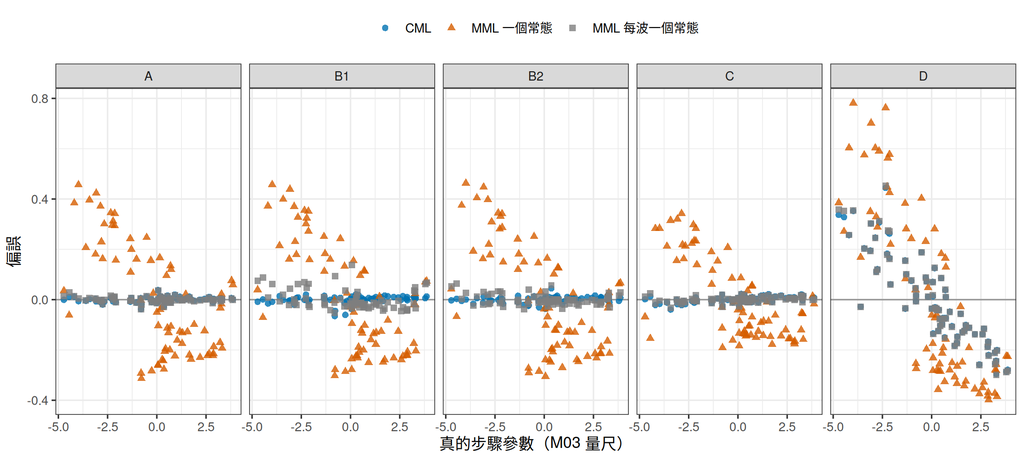

```r
ggplot(steps03, aes(true, bias, colour = calib, shape = calib)) +
  geom_hline(yintercept = 0, colour = "grey60") +
  geom_point(size = 1.8, alpha = 0.8) +
  facet_wrap(~scenario, nrow = 1) +
  method_look[c(1, 3:5)] +
  labs(x = "真的步驟參數（M03 量尺）", y = "偏誤")
```

- M03 的步驟參數平均偏誤都是 0：這是對齊的規則（平均等於真值的平均），不是結果。
- 要看的是每一步的偏誤絕對值。
- A：CML 0.008，MML 每波一個常態 0.008，MML 一個常態 0.187。
- CML 和每波一個常態的 RMSE 幾乎相同（0.105、0.105）：差異只是抽樣誤差。
- 一個常態的偏誤有方向：容易的步驟估高、難的步驟估低（圖），量尺被壓擠，和比較教學第 3 節真實資料看到的一樣。
- M36（連結後）：一個常態的步驟參數平均偏 -0.282，整條量尺往下移；CML 是 -0.003。
- B1（左偏）：每波一個常態開始偏離，M03 是 0.031（CML 0.010），M36 是 0.091（CML 0.037）。
- B2（混合）的偏離小一些：M03 0.016，CML 0.009。
- C（SD × 2）：CML 和每波一個常態一樣好（M03 0.010、0.008）；地板和天花板不影響題目參數。
- D（資料是 GPCM）：三種校準都偏，CML 0.146、每波一個常態 0.148。
- CML 不需要能力分佈的假設，但仍然需要 PCM；模型錯時它沒有比較好。

# 4 內部連結

這一節回答：M36 → M03 的直線，截距和斜率對不對？

真的截距是置中的 M36 量尺換到 M03 的平移（真的 M36 步驟參數的平均），真的斜率是 1。

```r
link <- part("link") |>
  mutate(calib = factor(CALIBS[calib], CALIBS))
link |>
  select(scenario, calib, intercept_bias, intercept_rmse, slope_bias, slope_rmse, mean_dropped) |>
  knitr::kable(digits = 3)
```

| scenario | calib | intercept_bias | intercept_rmse | slope_bias | slope_rmse | mean_dropped |
| --- | --- | --- | --- | --- | --- | --- |
| A | CML | -0.004 | 0.034 | -0.002 | 0.023 | 2.70 |
| A | MML 一個常態 | -0.281 | 0.283 | 0.010 | 0.026 | 2.52 |
| A | MML 每波一個常態 | -0.007 | 0.034 | -0.001 | 0.022 | 2.70 |
| B1 | CML | -0.002 | 0.040 | -0.002 | 0.024 | 2.86 |
| B1 | MML 一個常態 | -0.268 | 0.271 | 0.022 | 0.033 | 2.57 |
| B1 | MML 每波一個常態 | 0.034 | 0.053 | 0.026 | 0.036 | 2.71 |
| B2 | CML | -0.003 | 0.037 | 0.000 | 0.024 | 2.78 |
| B2 | MML 一個常態 | -0.279 | 0.282 | 0.018 | 0.032 | 2.60 |
| B2 | MML 每波一個常態 | 0.007 | 0.037 | 0.011 | 0.026 | 2.78 |
| C | CML | -0.001 | 0.049 | 0.000 | 0.025 | 2.57 |
| C | MML 一個常態 | -0.194 | 0.197 | -0.028 | 0.036 | 2.61 |
| C | MML 每波一個常態 | 0.002 | 0.035 | 0.000 | 0.022 | 2.69 |
| D | CML | -0.181 | 0.261 | -0.014 | 0.037 | 3.03 |
| D | MML 一個常態 | -0.450 | 0.483 | 0.007 | 0.036 | 2.66 |
| D | MML 每波一個常態 | -0.184 | 0.263 | -0.014 | 0.037 | 3.03 |

```r
lk <- function(sc, cal, col = "intercept_bias") {
  link[[col]][link$scenario == sc & link$calib == CALIBS[[cal]]]
}
```

- A：截距的偏誤，CML -0.004，每波一個常態 -0.007，一個常態 -0.281。
- 一個常態的截距偏誤是 CML 的 RMSE（0.034）的 8 倍：這不是抽樣誤差。
- 原因：一個常態把兩個世代各自壓擠，共同題的門檻在 M03 和 M36 被壓擠的方式不同（它們在 M03 是難題，在 M36 是容易的題）。
- 斜率的偏誤都小：A 的三種校準在 -0.002 到 0.010 之間。
- B1：每波一個常態的截距偏 0.034、斜率偏 0.026；CML 是 -0.002、-0.002。
- C：CML 和每波一個常態都準（-0.001、0.002）；一個常態是 -0.194。
- D：三種校準的截距都偏，CML -0.181，每波一個常態 -0.184，一個常態 -0.450。
- 篩選每次平均拿掉 2.52 到 3.03 個點（共同題每題 3 步，一步一個點）。

# 5 個人

這一節回答：每個孩子的能力值離真值多遠，95% 區間有沒有蓋到真值？

M36 的能力值是用連結換到 M03 量尺的值，所以連結的誤差也算在裡面。 區間：估法 1–3 是 WLE ± 1.96 SE，估法 4 是 EAP ± 1.96 SD.EAP；M36 的 SE 乘上連結的斜率。

```r
persons <- part("persons") |>
  mutate(method = factor(method, METHODS))
persons |>
  pivot_wider(id_cols = c(cohort, method), names_from = scenario,
              values_from = c(rmse, coverage)) |>
  arrange(cohort, method) |>
  knitr::kable(digits = 3)
```

| cohort | method | rmse_A | rmse_B1 | rmse_B2 | rmse_C | rmse_D | coverage_A | coverage_B1 | coverage_B2 | coverage_C | coverage_D |
| --- | --- | --- | --- | --- | --- | --- | --- | --- | --- | --- | --- |
| M03 | 1 CML + WLE | 0.511 | 0.512 | 0.511 | 0.582 | 0.613 | 0.955 | 0.955 | 0.955 | 0.952 | 0.877 |
| M03 | 2 MML 一個常態 + WLE | 0.566 | 0.568 | 0.567 | 0.621 | 0.692 | 0.918 | 0.918 | 0.918 | 0.927 | 0.815 |
| M03 | 3 MML 每波常態 + WLE | 0.511 | 0.513 | 0.510 | 0.583 | 0.613 | 0.953 | 0.951 | 0.952 | 0.949 | 0.873 |
| M03 | 4 MML 每波常態 + EAP | 0.400 | 0.426 | 0.397 | 0.542 | 0.536 | 0.923 | 0.881 | 0.905 | 0.950 | 0.808 |
| M36 | 1 CML + WLE | 0.434 | 0.433 | 0.437 | 0.601 | 0.581 | 0.952 | 0.953 | 0.952 | 0.948 | 0.807 |
| M36 | 2 MML 一個常態 + WLE | 0.510 | 0.508 | 0.511 | 0.669 | 0.714 | 0.864 | 0.870 | 0.866 | 0.879 | 0.675 |
| M36 | 3 MML 每波常態 + WLE | 0.434 | 0.449 | 0.441 | 0.592 | 0.582 | 0.951 | 0.953 | 0.952 | 0.944 | 0.804 |
| M36 | 4 MML 每波常態 + EAP | 0.396 | 0.397 | 0.393 | 0.573 | 0.563 | 0.946 | 0.954 | 0.950 | 0.949 | 0.794 |

```r
ps <- function(sc, coh, m, col = "rmse") {
  persons[[col]][persons$scenario == sc & persons$cohort == coh & persons$method == METHODS[m]]
}
```

依真的 θ 分 10 組（等寬，兩個世代合起來）的偏誤。 人數少於 200（所有複製合計）的組不畫。

```r
cond <- part("bins") |>
  summarise(theta = weighted.mean(theta, n), bias = weighted.mean(bias, n), n = sum(n),
            .by = c(scenario, method, bin)) |>
  filter(n >= 200) |>
  mutate(method = factor(method, METHODS))
```

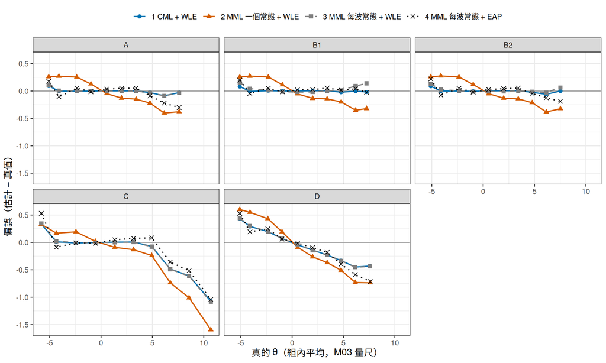

```r
ggplot(cond, aes(theta, bias, colour = method, linetype = method, shape = method)) +
  geom_hline(yintercept = 0, colour = "grey60") +
  geom_line(linewidth = 0.7) +
  geom_point(size = 2) +
  facet_wrap(~scenario, ncol = 3) +
  method_look +
  labs(x = "真的 θ（組內平均，M03 量尺）", y = "偏誤（估計 − 真值）")
```

```r
cb <- function(sc, m, which = c("low", "high")) {
  d <- cond |> filter(scenario == sc, method == METHODS[m]) |> arrange(theta)
  if (match.arg(which) == "low") d$bias[1] else d$bias[nrow(d)]
}
```

- RMSE：WLE 的三種估法裡，CML（0.511）和每波一個常態（0.511）在 A 的 M03 幾乎一樣。
- 一個常態最大：M03 0.566，M36 0.510（CML 的 M36 是 0.434）。
- EAP 的 RMSE 最小（A 的 M03 0.400）：往波次的平均縮，個別的誤差比較小。
- 涵蓋率：CML + WLE 在 A 是 95.5%（M03）和 95.2%（M36），接近 95%。
- 一個常態的 M36 只有 86.4%：連結的偏誤讓區間整個偏下去。
- EAP 的區間在 A 的 M03 已經只有 92.3%，在 B1 降到 88.1%：事前分佈不對時更差。
- D：每一種都不到 95%，CML + WLE 的 M36 只有 80.7%。
- 條件偏誤（圖）：A 最低的一組 CML + WLE 偏 0.09，最高的一組偏 -0.03。
- 這兩端是地板和天花板：0 分和滿分的 WLE 是有限的值，往中間拉。
- 中間的組，CML + WLE 和每波一個常態 + WLE 都在 0 附近，兩條線重疊。
- 一個常態 + WLE 是一條斜線：低的估高、高的估低（A 最低的一組 0.26，最高的一組 -0.38）。
- C 的兩端偏最多：CML + WLE 最高的一組偏 -1.07。

# 6 群體

這一節回答：每個世代 × 波次的平均、SD、P10、P50、P90，估出來的和同一群孩子真的值差多少？

M36 是連結以後的值。

```r
groups <- part("groups") |>
  mutate(method = factor(method, METHODS))
```

波次平均的偏誤：

```r
plot_wave_bias <- function(st, ylab) {
  ggplot(filter(groups, stat == st), aes(wave_m, bias, colour = method, linetype = method)) +
    geom_hline(yintercept = 0, colour = "grey60") +
    geom_line(linewidth = 0.7) +
    geom_point(aes(shape = method), size = 2) +
    facet_grid(cohort ~ scenario) +
    method_look + labs(x = "波次（月）", y = ylab)
}
```

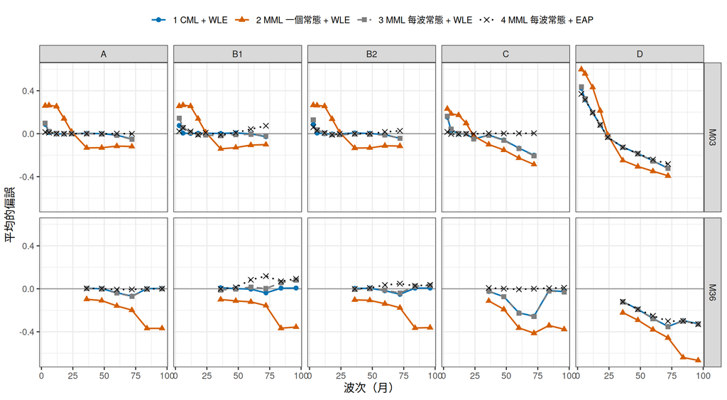

```r
plot_wave_bias("mean", "平均的偏誤")
```

SD 的偏誤：

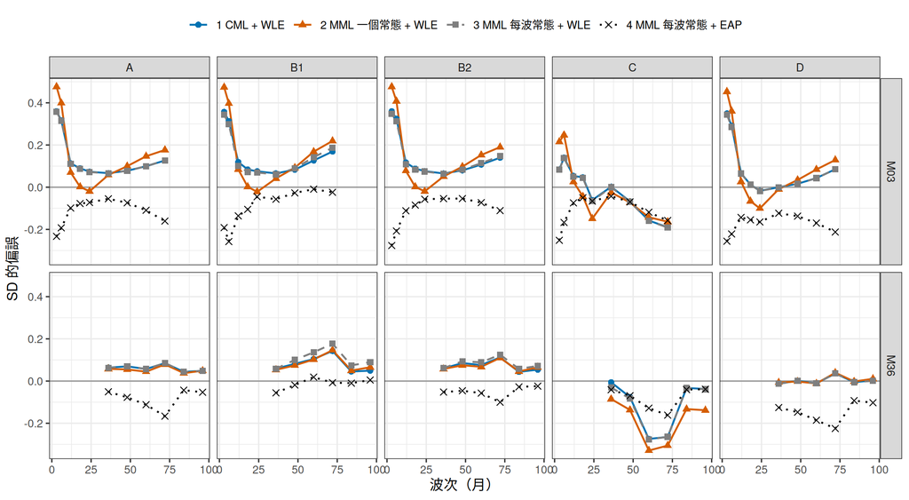

```r
plot_wave_bias("sd", "SD 的偏誤")
```

精簡的表：每個統計量在 15 個世代 × 波次的偏誤，取絕對值的最大值。

```r
group_tab <- groups |>
  summarise(max_abs_bias = max(abs(bias)), .by = c(scenario, method, stat)) |>
  pivot_wider(names_from = stat, values_from = max_abs_bias) |>
  arrange(scenario, method)
knitr::kable(group_tab, digits = 3)
```

| scenario | method | mean | sd | p10 | p50 | p90 |
| --- | --- | --- | --- | --- | --- | --- |
| A | 1 CML + WLE | 0.087 | 0.360 | 0.591 | 0.152 | 0.596 |
| A | 2 MML 一個常態 + WLE | 0.369 | 0.476 | 0.605 | 0.403 | 0.838 |
| A | 3 MML 每波常態 + WLE | 0.099 | 0.358 | 0.576 | 0.155 | 0.594 |
| A | 4 MML 每波常態 + EAP | 0.015 | 0.233 | 0.324 | 0.064 | 0.256 |
| B1 | 1 CML + WLE | 0.076 | 0.357 | 0.577 | 0.219 | 0.691 |
| B1 | 2 MML 一個常態 + WLE | 0.367 | 0.474 | 0.584 | 0.412 | 0.857 |
| B1 | 3 MML 每波常態 + WLE | 0.144 | 0.344 | 0.491 | 0.212 | 0.739 |
| B1 | 4 MML 每波常態 + EAP | 0.118 | 0.258 | 0.436 | 0.105 | 0.262 |
| B2 | 1 CML + WLE | 0.088 | 0.360 | 0.593 | 0.186 | 0.663 |
| B2 | 2 MML 一個常態 + WLE | 0.365 | 0.476 | 0.601 | 0.398 | 0.844 |
| B2 | 3 MML 每波常態 + WLE | 0.128 | 0.348 | 0.534 | 0.185 | 0.676 |
| B2 | 4 MML 每波常態 + EAP | 0.060 | 0.277 | 0.418 | 0.072 | 0.250 |
| C | 1 CML + WLE | 0.255 | 0.274 | 0.528 | 0.146 | 0.615 |
| C | 2 MML 一個常態 + WLE | 0.413 | 0.329 | 0.594 | 0.337 | 0.820 |
| C | 3 MML 每波常態 + WLE | 0.258 | 0.277 | 0.517 | 0.151 | 0.616 |
| C | 4 MML 每波常態 + EAP | 0.017 | 0.252 | 0.440 | 0.178 | 0.270 |
| D | 1 CML + WLE | 0.423 | 0.349 | 0.355 | 0.486 | 0.790 |
| D | 2 MML 一個常態 + WLE | 0.667 | 0.453 | 0.647 | 0.691 | 1.084 |
| D | 3 MML 每波常態 + WLE | 0.436 | 0.344 | 0.357 | 0.498 | 0.795 |
| D | 4 MML 每波常態 + EAP | 0.370 | 0.256 | 0.698 | 0.344 | 0.570 |

```r
gb <- function(sc, m, st) {
  group_tab[[st]][group_tab$scenario == sc & group_tab$method == METHODS[m]]
}
gw <- function(sc, m, st, coh, w) {
  g <- groups |> filter(scenario == sc, method == METHODS[m], stat == st)
  g$bias[g$cohort == coh & g$wave_m == w]
}
```

- 平均：A 的 CML + WLE，15 個波次裡最大的偏誤是 0.087（M03 的 3 個月：0.087，地板）。
- 每波一個常態 + WLE 和 CML 一樣（0.099）。
- 一個常態 + WLE 最大偏 0.369：M03 的 3 個月偏 0.26，M36 的 96 個月偏 -0.37。
- 一個常態會讓「M36 的孩子比 M03 低」，而這個差距是估法造成的。
- EAP 的波次平均最準（A 最大 0.015）：每個波次的事前分佈就是那個波次。
- SD：WLE 的 SD 偏大，因為測量誤差也算進去（A 的 3 個月 0.36）。
- EAP 的 SD 偏小，因為往平均縮（同一波 -0.23）。
- 所以 P10、P90 的方向相反：WLE 的 P10 偏低、P90 偏高；EAP 相反。
- 72 個月的 P90，WLE 偏 0.60：滿分的孩子都拿到同一個有限的 WLE，天花板。
- C 把這些放大：CML + WLE 平均的最大偏誤 0.255，EAP 0.017。
- D：所有估法的波次平均都偏，CML + WLE 最大 0.423；低的波次估高、高的波次估低，量尺被壓擠。

# 7 結論

這一節回答：數字說了什麼？

```r
same <- link |>
  filter(scenario %in% c("A", "B2", "C")) |>
  select(scenario, calib, intercept_bias) |>
  pivot_wider(names_from = calib, values_from = intercept_bias)
same_diff <- max(abs(same[[CALIBS[["CML"]]]] - same[[CALIBS[["MMLw"]]]]))
mml1_ac <- link$intercept_bias[link$calib == CALIBS[["MML1"]] & link$scenario != "D"]
```

1. **資料符合 PCM、每波常態時（A），CML 和每波一個常態的 MML 沒有差別。** 題目參數、連結、個人的 RMSE 和涵蓋率幾乎一樣；A、B2、C 的截距偏誤兩者最多差 0.011。 這兩種估法之間的差距，在真實資料上不用解釋成誰對誰錯。
2. **一個常態的 MML 是會錯的那一種。** M03 的步驟參數平均偏 0.187，連結的截距偏 -0.28，M36 每個孩子平均偏 -0.24。 A 到 C 的截距偏誤都在 -0.28 到 -0.19 之間：分佈的形狀不是主因，主因是它不知道波次。
3. **每波一個常態的 MML 對每波的形狀敏感，CML 不敏感。** 左偏（B1）時連結的截距偏 0.034，CML 是 -0.002；混合（B2）時兩者都準。 這個差距比一個常態的錯小 8 倍左右。
4. **地板和天花板（C）傷的是個人分數和波次的統計量，不是題目參數和連結。** CML 和每波一個常態的連結截距偏誤都在 0.002 以內。 但 WLE 的波次平均最多偏 0.255（A 是 0.087），在 0 分和滿分最多的波次。
5. **模型錯時（D），CML 也沒有保護。** CML 的截距偏 -0.18，和每波一個常態（-0.18）一樣。 CML 不需要分佈的假設，但仍然需要 PCM。
6. **WLE 和 EAP 的取捨。** EAP 個別的 RMSE 小、波次平均準，但 SD 和 P10、P90 往中間縮，區間的涵蓋率低於 95%，事前分佈不對時更低。 WLE 的波次平均（中段）也準，SD 偏大，兩端有地板和天花板。 兩者都不能直接給出正確的 SD 和百分位數。

# 8 限制

這一節回答：這些結論在哪些地方不能推廣？

- 只有語言領域；動作、認知的題本和題數不同。
- 每個世代 500 個孩子，和示範資料一樣；真實資料的人數不同，抽樣誤差也不同。
- 真值是從示範資料建出來的（示範資料本身也是模擬的），不是真實資料的參數。
- 真值是一個 PCM，共同題在兩個世代完全相同（沒有 DIF）；真實資料的共同題有世代間的差異。
- 沒有做接到 D 的連結。
- 每個情境 100 次複製。

# 參考文獻

- Andersen, E. B. (1970). Asymptotic properties of conditional maximum-likelihood estimators. *Journal of the Royal Statistical Society: Series B, 32*(2), 283–301.
- Bock, R. D., & Aitkin, M. (1981). Marginal maximum likelihood estimation of item parameters: Application of an EM algorithm. *Psychometrika, 46*(4), 443–459.
- Chalmers, R. P., & Adkins, M. C. (2020). Writing effective and reliable Monte Carlo simulations with the SimDesign package. *The Quantitative Methods for Psychology, 16*(4), 248–280.
- Firth, D. (1993). Bias reduction of maximum likelihood estimates. *Biometrika, 80*(1), 27–38.
- Magis, D. (2015). A note on weighted likelihood and Jeffreys modal estimation of proficiency levels in polytomous item response models. *Psychometrika, 80*(1), 200–204.
- Warm, T. A. (1989). Weighted likelihood estimation of ability in item response theory. *Psychometrika, 54*(3), 427–450.

```
#> [1] "ggplot2" "purrr"   "tidyr"   "dplyr"
```